# 4. Ancestral state reconstruction: parsimony priors versus Mk2 maximum likelihood

Phylodynamics.jl vignettes

Author

Simon D. W. Frost

Published

October 28, 2026

## Overview

Phylogeographic and host-jump analyses routinely reconstruct ancestral states on fixed time-trees using either:

1. **Maximum parsimony** (`parsimony_counts`), which minimizes the total number of host switches under a specified directional flow prior:
   - **Prior 1 ($1 \to 2$ Camin–Sokal)**: irreversible animal $\to$ human transitions ($J^{(0)}$),
   - **Prior 2 ($2 \to 1$ Reverse Camin–Sokal)**: irreversible human $\to$ animal transitions ($J^{(1)}$),
   - **Prior 3 (Bidirectional Fitch)**: unconstrained $1 \leftrightarrow 2$ transitions ($J_F = J_{F,12} + J_{F,21}$); or
2. **Continuous-time Markov chain (“mugration” / Mk2) maximum likelihood** (`fit_mk2_ml`), which models host state as a neutral trait evolving along the branches of the phylogeny with generator
   $$Q = \begin{pmatrix} -q_{12} & q_{12} \\ q_{21} & -q_{21} \end{pmatrix},$$
   fitted via Felsenstein’s pruning algorithm and paired with conditional stochastic character mapping to estimate expected branch jumps and jump times.

This vignette demonstrates how `parsimony_counts` and `fit_mk2_ml` behave across Models 1, 2, and 3, why Mk2 transition rate estimates $\hat{q}_{12}$ and $\hat{q}_{21}$ scale in *opposite directions* with reservoir sample size $n_1$, and how inferred jump times compare against true transmission times.

## Fitting parsimony and Mk2 ML on simulated phylogenies

```julia
using Phylodynamics
using CairoMakie
using DataFrames
using StableRNGs
using Statistics
using Printf

rng = StableRNG(2026)
t1 = simulate_coalescent_tree(model1_params(); n1 = 100, n2 = 50, rng = rng)
t2 = simulate_coalescent_tree(model2_params(); n1 = 100, n2 = 50, rng = rng)
t3 = simulate_coalescent_tree(model3_params(); n1 = 100, n2 = 50, rng = rng)

rows = NamedTuple[]
for (mname, tr) in [("Model 1 (Spillover)", t1), ("Model 2 (Human Spread)", t2), ("Model 3 (Reverse Zoonosis)", t3)]
    pc = parsimony_counts(tr)
    mk = fit_mk2_ml(tr; n_maps = 100, rng = rng)
    push!(rows, (
        Model = mname,
        True_J12 = tr.true_jumps_12,
        True_J21 = tr.true_jumps_21,
        CS_1to2 = pc.J_pars_1to2,
        CS_2to1 = pc.J_pars_2to1,
        Fitch = pc.J_pars_fitch,
        Mk2_Unidir = round(mk.J_ml_unidir, digits = 2),
        Mk2_Bidir_12 = round(mk.J_ml_bidir_12, digits = 2),
        Mk2_Bidir_21 = round(mk.J_ml_bidir_21, digits = 2),
        q12_hat = round(mk.q_unidir, digits = 4),
        LRT_bidir = round(mk.LRT_bidir, digits = 2)
    ))
end
DataFrame(rows)
```

3×11 DataFrame

| Row | Model String | True_J12 Int64 | True_J21 Int64 | CS_1to2 Int64 | CS_2to1 Int64 | Fitch Int64 | Mk2_Unidir Float64 | Mk2_Bidir_12 Float64 | Mk2_Bidir_21 Float64 | q12_hat Float64 | LRT_bidir Float64 |
| --- | --- | --- | --- | --- | --- | --- | --- | --- | --- | --- | --- |
| 1 | Model 1 (Spillover) | 50 | 0 | 42 | 71 | 42 | 42.0 | 45.81 | 0.0 | 0.0525 | 0.0 |
| 2 | Model 2 (Human Spread) | 22 | 0 | 21 | 51 | 21 | 21.0 | 21.07 | 0.0 | 0.0253 | 0.0 |
| 3 | Model 3 (Reverse Zoonosis) | 16 | 14 | 21 | 48 | 18 | 21.0 | 17.55 | 6.44 | 0.026 | 18.77 |

Under unidirectional $1 \to 2$ Mk2 (`q21 = 0`, root in state 1), any internal node with at least one state-1 descendant must have ancestral state 1 with probability 1. Consequently, unidirectional Mk2 conditional stochastic mapping recovers the exact $1 \to 2$ Camin–Sokal parsimony count ($J_{\text{ML,unidir}} = J^{(0)}$).

## Opposite sample-size scaling of Mk2 rates $\hat{q}_{12}$ and $\hat{q}_{21}$

We can verify this directly across reservoir sample sizes $n_1 \in [1, 100]$ ($n_2 = 10$):

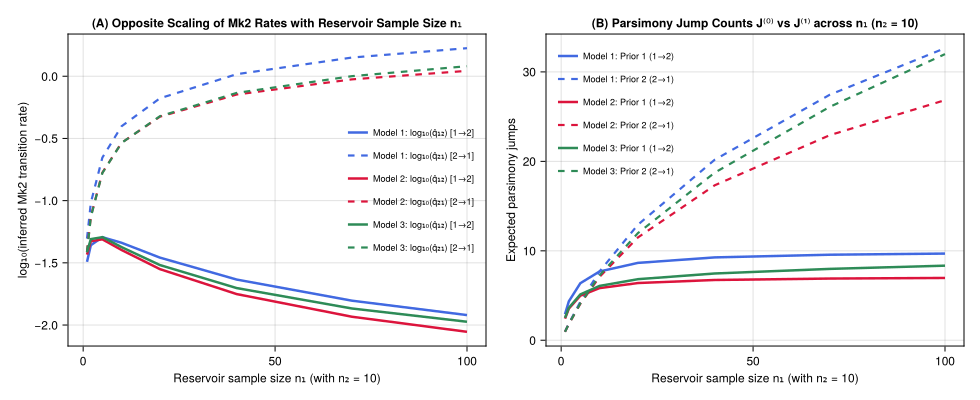

```julia
ode_n1_grid = [1, 2, 5, 10, 20, 40, 70, 100]
scaling_rows = NamedTuple[]

for (mname, zp) in [("Model 1", model1_params()), ("Model 2", model2_params()), ("Model 3", model3_params())]
    for n1_v in ode_n1_grid
        s = solve_coalescent_odes(zp; n1 = Float64(n1_v), n2 = 10.0).summary
        q12_approx = s.J_pars_1to2 / max(s.L1_true, 1.0)
        q21_approx = s.J_pars_2to1 / max(s.L2_true, 1.0)
        push!(scaling_rows, (
            model = mname, n1 = n1_v,
            log_q12 = log10(q12_approx),
            log_q21 = log10(q21_approx),
            J_1to2 = s.J_pars_1to2,
            J_2to1 = s.J_pars_2to1
        ))
    end
end
df_scale = DataFrame(scaling_rows)

fig = Figure(size = (980, 400), fontsize = 12)
ax1 = Axis(fig[1, 1];
    title = "(A) Opposite Scaling of Mk2 Rates with Reservoir Sample Size n₁",
    xlabel = "Reservoir sample size n₁ (with n₂ = 10)",
    ylabel = "log₁₀(inferred Mk2 transition rate)"
)
ax2 = Axis(fig[1, 2];
    title = "(B) Parsimony Jump Counts J⁽⁰⁾ vs J⁽¹⁾ across n₁ (n₂ = 10)",
    xlabel = "Reservoir sample size n₁ (with n₂ = 10)",
    ylabel = "Expected parsimony jumps"
)

cols = Dict("Model 1" => :royalblue, "Model 2" => :crimson, "Model 3" => :seagreen)
for mname in ["Model 1", "Model 2", "Model 3"]
    sub = filter(r -> r.model == mname, df_scale)
    lines!(ax1, sub.n1, sub.log_q12; color = cols[mname], linewidth = 2.5, label = "$mname: log₁₀(q̂₁₂) [1→2]")
    lines!(ax1, sub.n1, sub.log_q21; color = cols[mname], linewidth = 2.2, linestyle = :dash, label = "$mname: log₁₀(q̂₂₁) [2→1]")
    lines!(ax2, sub.n1, sub.J_1to2; color = cols[mname], linewidth = 2.5, label = "$mname: Prior 1 (1→2)")
    lines!(ax2, sub.n1, sub.J_2to1; color = cols[mname], linewidth = 2.2, linestyle = :dash, label = "$mname: Prior 2 (2→1)")
end
axislegend(ax1; position = :rc, framevisible = false, labelsize = 9)
axislegend(ax2; position = :lt, framevisible = false, labelsize = 9)
fig
```

## Comparing true transmission jump times vs. Mk2 mapped jump times

When `fit_mk2_ml` samples jump times along transition branches under a time-homogeneous rate $\hat{q}_{12}$, jumps on long external/internal branches are spread uniformly-to-exponentially over the branch rather than concentrated near the epidemic peak where prevalence $Y_1(t)$ is highest:

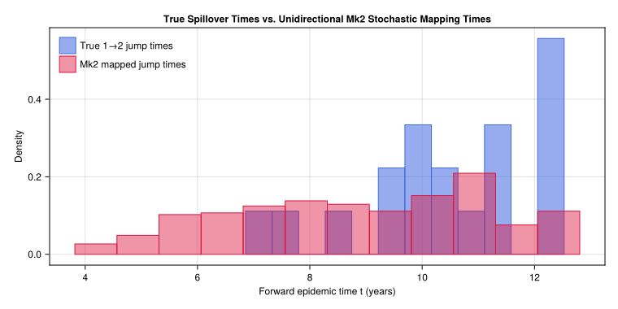

```julia
sim3 = simulate_forward_backward_tree(model3_params(); n1 = 100, n2 = 30, rng = StableRNG(2026))
mk3 = fit_mk2_ml(sim3.binary_tree; n_maps = 100, rng = StableRNG(2026))

fig_t = Figure(size = (760, 380), fontsize = 12)
ax_t = Axis(fig_t[1, 1];
    title = "True Spillover Times vs. Unidirectional Mk2 Stochastic Mapping Times",
    xlabel = "Forward epidemic time t (years)",
    ylabel = "Density"
)
if !isempty(sim3.binary_tree.true_jump_times_12)
    hist!(ax_t, sim3.binary_tree.true_jump_times_12; bins = 12, normalization = :pdf,
        color = (:royalblue, 0.55), strokewidth = 1, strokecolor = :royalblue, label = "True 1→2 jump times")
end
if !isempty(mk3.uni_jump_times)
    hist!(ax_t, mk3.uni_jump_times; bins = 12, normalization = :pdf,
        color = (:crimson, 0.45), strokewidth = 1, strokecolor = :crimson, label = "Mk2 mapped jump times")
end
axislegend(ax_t; position = :lt, framevisible = false)
fig_t
```